# proj1-WeixuanChen

Weixuan Chen

2/16/2023

## Problem 1

## 1

By Bayes Theorem,p(f2|d) = p(d|f2)*p(f2)/p(d). p(d|f2) = 0.7, p(f2) = 0.6. And by the law of total probability, p(d) = p(d|f2)p(f2) + p(d|not f2)p(not f2) = 0.7 x 0.6 + 0.1 x 0.4, so we can finalize the result in the code below.

```r
pDF2 = 0.7
pF2 =0.6
pDNF2 = 0.1
pD = pDF2 * pF2 + pDNF2 * (1 - pF2)
pF2D = pDF2*pF2/pD
pF2D
```

```
## [1] 0.9130435
```

## 2

```r
p.F2 <- seq(0.1, 0.9, length.out = 100)
p.F2.D.1 <- c()
for (i in 1:100){
    pD.F2 = 0.7
    pD.NF2 = 0.1
    p.D = pD.F2 * p.F2[i] + pD.NF2 * (1 - p.F2[i])
    pF2.D = pD.F2*p.F2[i]/p.D
    p.F2.D.1 <- append(p.F2.D.1,pF2.D)
}

p.F2.D.1
```

```
##   [1] 0.4375000 0.4589461 0.4791667 0.4982639 0.5163288 0.5334430 0.5496795
##   [8] 0.5651042 0.5797764 0.5937500 0.6070736 0.6197917 0.6319444 0.6435688
##  [15] 0.6546986 0.6653646 0.6755952 0.6854167 0.6948529 0.7039263 0.7126572
##  [22] 0.7210648 0.7291667 0.7369792 0.7445175 0.7517960 0.7588277 0.7656250
##  [29] 0.7721995 0.7785618 0.7847222 0.7906901 0.7964744 0.8020833 0.8075249
##  [36] 0.8128064 0.8179348 0.8229167 0.8277582 0.8324653 0.8370434 0.8414977
##  [43] 0.8458333 0.8500548 0.8541667 0.8581731 0.8620781 0.8658854 0.8695988
##  [50] 0.8732215 0.8767570 0.8802083 0.8835784 0.8868702 0.8900862 0.8932292
##  [57] 0.8963015 0.8993056 0.9022436 0.9051178 0.9079301 0.9106826 0.9133772
##  [64] 0.9160156 0.9185997 0.9211310 0.9236111 0.9260417 0.9284241 0.9307598
##  [71] 0.9330502 0.9352965 0.9375000 0.9396619 0.9417835 0.9438657 0.9459098
##  [78] 0.9479167 0.9498874 0.9518229 0.9537242 0.9555921 0.9574275 0.9592313
##  [85] 0.9610043 0.9627472 0.9644608 0.9661458 0.9678030 0.9694331 0.9710366
##  [92] 0.9726142 0.9741667 0.9756944 0.9771982 0.9786784 0.9801357 0.9815705
##  [99] 0.9829835 0.9843750
```

```r
p.D.not.F2 <- seq(0.01, 0.5, length.out = 100)
p.F2.D.2 <- c()
for (i in 1:100){
    pD.F2 = 0.7
    pF.2 = 0.6
    p.D = pD.F2 * pF.2+ p.D.not.F2[i] * (1 - pF.2)
    pF2.D = pD.F2*pF.2/p.D
    p.F2.D.2 <- append(p.F2.D.2,pF2.D)
}

p.F2.D.2
```

```
##   [1] 0.9905660 0.9859622 0.9814011 0.9768819 0.9724041 0.9679672 0.9635706
##   [8] 0.9592138 0.9548962 0.9506173 0.9463765 0.9421735 0.9380076 0.9338784
##  [15] 0.9297853 0.9257280 0.9217060 0.9177187 0.9137658 0.9098468 0.9059613
##  [22] 0.9021088 0.8982890 0.8945013 0.8907455 0.8870211 0.8833277 0.8796649
##  [29] 0.8760324 0.8724297 0.8688566 0.8653126 0.8617974 0.8583106 0.8548520
##  [36] 0.8514211 0.8480176 0.8446413 0.8412917 0.8379686 0.8346716 0.8314005
##  [43] 0.8281549 0.8249345 0.8217391 0.8185684 0.8154220 0.8122998 0.8092013
##  [50] 0.8061264 0.8030748 0.8000462 0.7970403 0.7940570 0.7910959 0.7881568
##  [57] 0.7852395 0.7823436 0.7794691 0.7766156 0.7737829 0.7709709 0.7681791
##  [64] 0.7654076 0.7626559 0.7599240 0.7572115 0.7545184 0.7518444 0.7491892
##  [71] 0.7465527 0.7439347 0.7413350 0.7387535 0.7361898 0.7336439 0.7311155
##  [78] 0.7286045 0.7261106 0.7236338 0.7211739 0.7187306 0.7163037 0.7138933
##  [85] 0.7114990 0.7091207 0.7067582 0.7044115 0.7020802 0.6997644 0.6974638
##  [92] 0.6951782 0.6929076 0.6906518 0.6884106 0.6861839 0.6839716 0.6817735
##  [99] 0.6795894 0.6774194
```

```r
length(p.F2)
```

```
## [1] 100
```

```r
length(p.F2.D.1)
```

```
## [1] 100
```

## 3

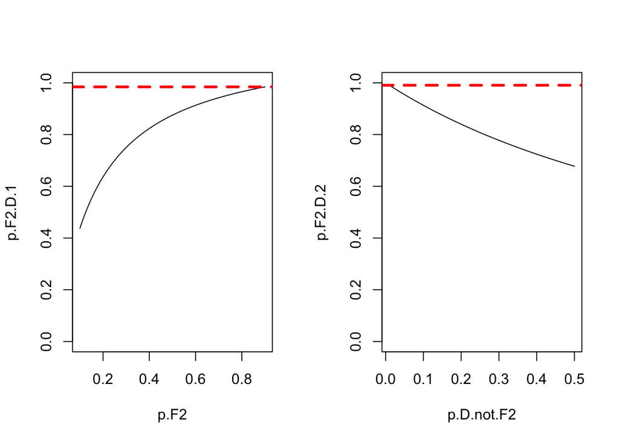

```r
par(mfrow = c(1,2))
plot(p.F2, p.F2.D.1, type = "l", ylim = c(0,1))
abline(h = max(p.F2.D.1), col="red", lwd=3, lty=2)
plot(p.D.not.F2, p.F2.D.2, type = "l", ylim = c(0,1))
abline(h = max(p.F2.D.2), col="red", lwd=3, lty=2)
```

## 4

For the p(f2), the increase of p(f2) makes the p(f2|d) increase. In the contrary, for the p(d|not f2), the increase of p(d|not f2) makes p(f2|d) decrease. It is obvious that p(f2) is worse to be uncertain about, because given 100 simulated numbders, the range of p(f2|d) is greater on p(f2) than p(d|not f2).

## Problem 2

```r
d1 <- read.csv(file = "http://faraway.neu.edu/biostats/assn1_dataset1.csv")
d1
```

```
##          flu age
## 1      swine  30
## 2      swine  35
## 3      swine  45
## 4      swine  62
## 5      swine  27
## 6      swine  61
## 7      swine  64
## 8      swine  50
## 9      swine  48
## 10     swine  20
## 11     swine  27
## 12     swine  25
## 13     swine  51
## 14     swine  36
```

[output cut: 146 more lines]

## 2

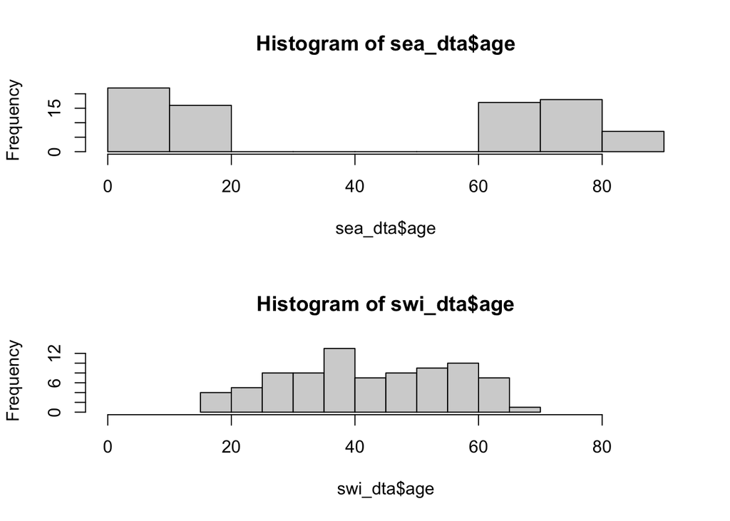

```r
sea_dta <- subset(d1, flu == "seasonal")
swi_dta <- subset(d1, flu == "swine")

par(mfrow = c(2,1))
hist(sea_dta$age, xlim=c(0,90))
hist(swi_dta$age, xlim=c(0,90))
```

## 3

Apparently, these two flu target different groups of people, because the first plot has separate bars and the second plot has centered bars.

## 4

```r
cheld_dta <- subset(d1, age < 18 | age > 65)
adt_dta <- subset(d1, 18 <= age & age <= 65)

children_dta <- aggregate(cheld_dta$age, list(cheld_dta$flu), FUN=length)
adult_dta <- aggregate(adt_dta$age, list(adt_dta$flu), FUN=length)
children_dta
```

```
##    Group.1  x
## 1 seasonal 73
## 2    swine  2
```

```r
adult_dta
```

```
##    Group.1  x
## 1 seasonal  7
## 2    swine 78
```

```r
dta_cmb <- children_dta
dta_cmb["adult"] = adult_dta$x
colnames(dta_cmb) <- c("flu","children/elder", "adult")
dta_cmb
```

```
##        flu children/elder adult
## 1 seasonal             73     7
## 2    swine              2    78
```

## 5

```r
rownames(dta_cmb) <- dta_cmb$flu
dta_cmb <- data.frame(dta_cmb$`children/elder`, dta_cmb$adult)
dta_cmb
```

```
##   dta_cmb..children.elder. dta_cmb.adult
## 1                       73             7
## 2                        2            78
```

```r
chisqr <- chisq.test(dta_cmb)
chisqr
```

```
##
##  Pearson's Chi-squared test with Yates' continuity correction
##
## data:  dta_cmb
## X-squared = 122.98, df = 1, p-value < 2.2e-16
```

From the p-value, which is 2.2e-16, we can reject the null hypothesis at any significance level possible. So we can conclude that we have enough evidence to show they have association.